# Final Project - Machine Learning

Omry Yoresh

June 2023

# 1. Introduction:

Construction accidents posed a significant threat to worker safety, productivity, and the economy at large. Simultaneously, air pollution has emerged as a global concern, impacting various aspects of human life. Understanding the relationship between the two, stands as a crucial point in order to improve workplace safety and mitigating the adverse effects of pollution. This project aims to extend the main results of the paper “Heads Up: Does Pollution Cause Construction Accidents?” by Victor Lavy, Genia Rachkovsky, and myself, within the framework of the course “Machine Learning for Economists” at The Hebrew University of Jerusalem.

The original study examined the impact of Nitrogen Dioxide ($NO_2$) on construction accidents. Building upon this research, this project leverages machine learning techniques and methodologies learned in the course to further explore and validate the findings. To accomplish this, the project adopts a two-fold approach. First, a double lasso methodology is employed to validate the controls selected for analyzing the effect of $NO_2$. The availability of multiple pollutants and weather variables, this analysis identifies the most influential factors associated with construction accidents, that are important for the estimation. It also potentially addresses concerns of co-determination of pollution in both time and space, enhancing the robustness of the original findings.

Moreover, the project goes beyond replication and validation by incorporates a Ridge prediction model. This model aims to assess the likelihood of a construction accident at a given construction site. A comparative analysis was conducted to evaluate the accuracy of the model using same-day data versus lagged data. This analysis holds potential policy implications, as it could inform decisions regarding safety protocols. Understanding the predictive power of different time frames can also be crucial for effectively managing construction site safety and labor allocation.

The project is organized as follows: Chapter 2 focuses on data replication to ensure consistency with the original study. Chapter 3 employs the double lasso method to validate the chosen pollution variables and explore potential regressors. Chapter 4 compares and develops prediction models to assess the likelihood of construction accidents using both same-day and lagged data. Finally, Chapter 5 summarizes the key findings, discuses their implications, and provide recommendations for policymakers.

# 2. Data Replication

### 2.1 Data Preparation

The dataset used in this paper combined data from three primary sources: the Israeli Ministry of Economy and Industry, which provided information on construction sites’ locations, activity dates, and construction accidents between 2017 and 2019; the Israeli Ministry of Environmental Protection, which provided measurements of air pollution and weather during the same period; and Kav LaOved, a nonprofit organization focused on workers’ rights, which supplemented the construction site accident data.

### 2.1.1 Construction Sites

Initially, the Ministry of Economy and Industry provided a sample of 25,571 active construction sites in Israel from 2017 to 2019. By applying geocoding techniques, the sites’ addresses were matched to their respective coordinates. Each active day for each site was then assigned an observation, resulting in a final sample of 24,614 sites and 10,016,000 observations.

### 2.1.2 Accidents

The accident sample provided by the Ministry of Economy and Industry included 1,316 accidents within the specified period. However, the accidents provided by Kav LaOved did not have site IDs that matched the ministry’s data. Therefore, the accidents were matched to the sites based on their addresses, resulting in an additional 31 accidents. By merging the dataset of the site’s active days and the accidents, a total of 1,164 accidents were recorded per 10,016,000 working days in construction sites.

### 2.1.3 Environmental Data

Air pollution and weather data were obtained from the Israeli Ministry of Environmental Protection. The data includes 8-hour average measurements of various pollutants such as Nitrogen Dioxide ($NO_2$), wind strength and direction, temperature, humidity, and other pollutants from 173 monitoring stations across Israel during the sample period. Each active day in a construction site was assigned the nearest reading for each variable, with 7,199 construction sites having at least one monitoring station within a 1 km distance.

### 2.2 Summary Statistics

Summary statistics were computed for all the pollutants and weather variables in the data. The following table (Table 1) presents the average rates and standard errors of the various variables:

Load libraries:

```r
set.seed(42)
if (!require("pacman")) install.packages("pacman")
```

```r
pacman::p_load(
  tidyverse,     # for data wrangling
  tidymodels,    # for ml regressions
  broom,         # convert results to tidy objects
  fastDummies,   # for turning categorical variables into sets of dummies
  fixest,        # for twfe estimation and se clustering
  hdm,           # for double lasso
  gridExtra,     # for graphs
  haven,         # uploading dta files
  rpart,         # for random forest
  rattle,        # for data mining
  magrittr,      # for piping operations
  caret,         # for machine learning modeling
  DALEX,         # for model explanations
  rpart.plot,    # for plotting decision trees
  RColorBrewer,  # for color palettes
  ada,           # for adaptive boosting
  doParallel,    # for parallel computing
  ggplot2,       # for data visualization
  kableExtra,    # for creating tables
  rsample,       # for data splitting
  GGally,        # for pairwise plots
  broom,         # convert results to tidy objects
  glmnet,        # for elastic net regularization
  yardstick      # for model evaluation metrics
  )
```

Loading raw pollution data:

```r
load("/Users/omry/Documents/GitHub/Heads-Up--Does-Air-Pollution-Cause-Workplace-Accidents/Data/Process/Pollution.Rda")
```

I first create the summary statistics of the pollutants and weather variables (Table 1).

```r
pollution_data_tidy <- pollution %>%
  pivot_longer(cols = c("no2_08", "no2_16", "no2_24", "pm25_08",
                        "pm25_16", "pm25_24", "temp_08", "temp_16",
                        "temp_24", "wind_08", "wind_16", "wind_24",
                        "humidity_08", "humidity_16", "humidity_24",
                        "so2_08", "so2_16", "so2_24", "o3_08", "o3_16",
                        "o3_24", "pm10_08", "pm10_16", "pm10_24", "co_08",
                        "co_16", "co_24"),
               names_to = c("Pollutant", "Hour Measured"),
               names_sep = "_")

pollution_summary <- pollution_data_tidy %>%
  group_by(Pollutant, `Hour Measured`) %>%
  summarise(Units = ifelse(grepl("no2", Pollutant), "ppb",
                    ifelse(grepl("pm", Pollutant), "µg/m3",
                    ifelse(grepl("temp", Pollutant), "Celsius",
                    ifelse(grepl("wind", Pollutant), "m/sec",
                    ifelse(grepl("humidity", Pollutant), "%",
                    ifelse(grepl("so2", Pollutant), "ppb",
                    ifelse(grepl("o3", Pollutant), "ppb",
                    ifelse(grepl("pm10", Pollutant), "µg/m3",
                    ifelse(grepl("co", Pollutant), "ppm", NA
                           ))))))))),
            Monitors = n_distinct(mon_id, na.rm = TRUE),
            Obs = sum(!is.na(value)),
            `Average Rate` = round(mean(value, na.rm = TRUE), 1),
            `Standard Error` = round(sd(value, na.rm = TRUE), 1),
            .groups = "drop_last") %>%
  arrange(Pollutant, `Hour Measured`) %>%
  unique()
```

| Pollutant | Hour Measured | Units | Monitors | Obs | Average Rate | Standard Error |
| --- | --- | --- | --- | --- | --- | --- |
| co | 08 | ppm | 173 | 16709 | 0.4 | 0.5 |
| co | 16 | ppm | 173 | 16590 | 0.4 | 0.6 |
| co | 24 | ppm | 173 | 16786 | 0.4 | 0.6 |
| humidity | 08 | % | 173 | 88684 | 72.4 | 18.5 |
| humidity | 16 | % | 173 | 91280 | 52.6 | 15.8 |
| humidity | 24 | % | 173 | 91362 | 66.2 | 17.4 |
| no2 | 08 | ppb | 173 | 136492 | 10.9 | 9.9 |
| no2 | 16 | ppb | 173 | 134707 | 10.1 | 18.0 |
| no2 | 24 | ppb | 173 | 136697 | 12.4 | 14.9 |
| o3 | 08 | ppb | 173 | 64352 | 27.1 | 13.2 |
| o3 | 16 | ppb | 173 | 63993 | 45.9 | 10.7 |
| o3 | 24 | ppb | 173 | 64583 | 36.0 | 11.9 |
| pm10 | 08 | µg/m3 | 173 | 23285 | 44.3 | 53.6 |
| pm10 | 16 | µg/m3 | 173 | 23021 | 55.6 | 70.6 |
| pm10 | 24 | µg/m3 | 173 | 23379 | 48.1 | 54.6 |
| pm25 | 08 | µg/m3 | 173 | 65170 | 20.8 | 12.5 |
| pm25 | 16 | µg/m3 | 173 | 64317 | 21.3 | 14.8 |
| pm25 | 24 | µg/m3 | 173 | 65343 | 20.6 | 16.0 |
| so2 | 08 | ppb | 173 | 86180 | 0.8 | 0.9 |
| so2 | 16 | ppb | 173 | 85921 | 1.2 | 1.7 |
| so2 | 24 | ppb | 173 | 86641 | 0.9 | 1.1 |
| temp | 08 | Celsius | 173 | 111176 | 18.9 | 6.0 |
| temp | 16 | Celsius | 173 | 111156 | 24.7 | 6.4 |
| temp | 24 | Celsius | 173 | 111649 | 21.5 | 6.2 |
| wind | 08 | m/sec | 173 | 101905 | 1.8 | 1.3 |
| wind | 16 | m/sec | 173 | 101981 | 3.3 | 1.4 |
| wind | 24 | m/sec | 173 | 102253 | 2.3 | 1.2 |

Next I plot the distribution of the construction accidents by days of the week and months:

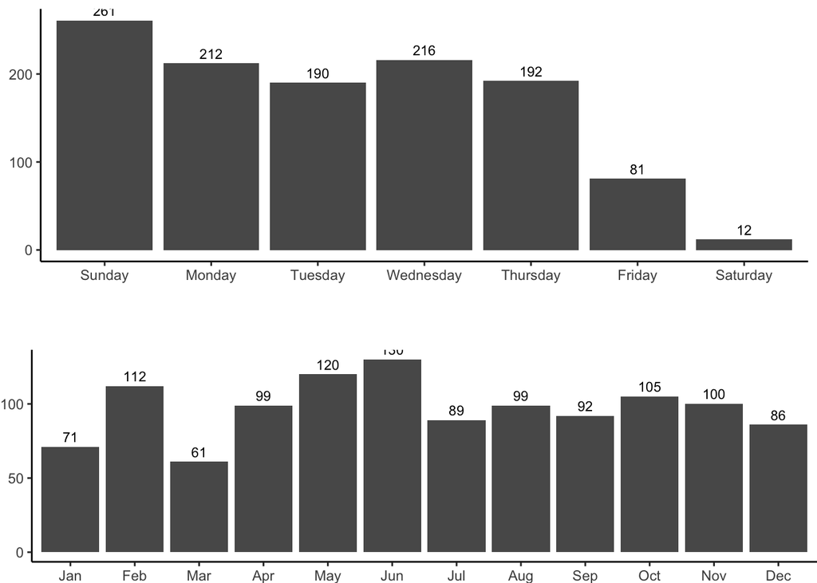

```r
load("/Users/omry/Documents/GitHub/Heads-Up--Does-Air-Pollution-Cause-Workplace-Accidents/Data/Final/Pollution and Accidents - Final.Rda")

data$dayofweek <- factor(data$dayofweek, levels = c("Sunday", "Monday",
                                                    "Tuesday", "Wednesday",
                                                    "Thursday", "Friday", "Saturday"))

# Converting day of the week to a factor with levels ordered
accidents_dayweek <- aggregate(acc ~ dayofweek, data, FUN = sum)

# Creating a data-frame with counts of accidents by day of week
p1 <- ggplot(accidents_dayweek, aes(x = dayofweek, y = acc)) +
  geom_bar(stat = "identity") +
  geom_text(aes(label = acc), vjust = -0.5, size = 3) +
  theme(axis.text.x = element_text(angle = 45, hjust = 1)) +
  labs(x = NULL, y = NULL) +
  theme_classic() +
  scale_fill_manual(values = rainbow(7))

# Creating a bar chart for day of week:
accidents_month <- aggregate(acc ~ month, data, FUN = sum)
accidents_month$month <- month.abb[accidents_month$month]

# Creating a data-frame with counts of accidents by month
p2 <- ggplot(accidents_month, aes(x = month, y = acc)) +
  geom_bar(stat = "identity", position = "dodge") +
  geom_text(aes(label = acc), vjust = -0.5, size = 3) +
  theme(axis.text.x = element_text(angle = 45, hjust = 1)) +
  labs(x = NULL, y = NULL) +
  theme_classic() +
  scale_x_discrete(labels = c("Jan", "Feb", "Mar", "Apr", "May", "Jun",
                                              "Jul", "Aug", "Sep", "Oct", "Nov", "Dec")) +
  scale_fill_manual(values = rainbow(3))

p2 <- p2 + theme(plot.margin = margin(0.5, 0, 0, 0, "in"))
p <- grid.arrange(p1, p2, ncol = 1, nrow = 2, heights = c(4, 4))
```

```r
rm(data, accidents_dayweek, accidents_month, p, p1, p2)
```

# 2.3 Econometric Framework and Main Analysis:

### 2.3.1 Econometric Framework:

The main analysis in this paper employed a linear probability fixed effects model to estimate the effect of $\beta$ in the following equation:
$$Y_{st} = \alpha + \beta NO_2+f(Temp_{st}, Wind_{st},
Hum_{st})+S_s+DMY_t+\epsilon_{st} ,$$
In this equation, $s$ represents the construction site index, while $t$ represents the day index. The outcome variable $Y_{st}$ is a binary indicator that determines whether an accident occurred at construction site $s$ on day $t$. The nitrogen dioxide level ($NO_2$) measured in parts per billion ($ppb$) at the monitoring station closest to the construction site between 8 am and 4 pm was included as the independent variable. The equation also includes construction site fixed effects denoted as $S_s$ and time fixed effects denoted as $DMY_t$ (day of the week, month, and year). The weather variables, $f(Temp_{st}, Wind_{st}, Hum_{st})$, represents temperature, wind speed, and humidity levels, respectively, along with the squared weather measurements obtained from the closest monitoring station. The idiosyncratic error term is denoted $\epsilon_{st}$, and standard errors are clustered in the construction site level.

The objective of this model is to address several challenges in establishing a causal relationship between pollution levels and the likelihood of a construction accident. The first challenge is the potential endogeneity of pollution levels due to their correlation with environmental factors such as temperature, wind, and humidity. To mitigate this issue, the model includes flexible controls for weather variables in the regression function.

The second challenge also involves endogeneity which might be associated with specific permanent attributes of each construction site. If pollution levels varies among contractors with different safety standards or if less experienced workers are more likely to work in regions with higher pollution levels, endogeneity arises. To account for this, the model incorporates construction site fixed effects, allowing for an examination of within-construction site variations in pollution levels and accident probabilities.

Measurement error is another potential concern in consideration of the impact of air pollution. When the density of monitoring stations or the frequency of measurements is low, the risk of biased results due to measurement error increases. To address this issue, the analysis takes advantage of a large number of monitoring stations spread across the country. The observations are limited to construction sites with a monitoring station within a 1 km radius. Additionally, pollution levels during working hours (8 am to 4 pm) are used since readings are available for three different intervals per day (the others are midnight to 8 am, and 4 pm to midnight).

A major concern is that high pollution levels may originate from the construction site itself on busy or specific days when the accident likelihood is higher. To address this concern, the analysis employs two instrumental variable approaches. Firstly, pollution levels at the nearest monitoring station (within a 1 km radius) are instrumented using average pollution levels from stations within a 5–10 km radius. This assumes that any pollution generated at the construction site would have minimal impact on monitoring stations located more than 5 km away.

Secondly, lagged pollution levels measured at the closest monitoring station during the preceding night are used as an instrument. This instrument assumes that pollution levels measured the night before only influence the probability of a construction accident during working hours on the same day through pollution levels measured during those working hours. It is also assumes that pollution generated by the site itself cannot affect pollution levels measured the previous night when the site is largely inactive.

Formally, the instrumental variable model is represented by the following equations:

First Stage:
$$NO_{2st} = \alpha+\lambda NO_{2s,t-0.5}+f(Temp_{st}, Wind_{st},
Hum_{st})+S_s+DMY_t+\nu_{st}$$

$$NO_{2st} = \alpha+\lambda NO_{2g_{5-10km},st}+f(Temp_{st}, Wind_{st},
Hum_{st})+S_s+DMY_t+\mu_{st}$$

Second Stage:
$$Y_{st} = \alpha + \beta Pred(NO_2)+f(Temp_{st}, Wind_{st},
Hum_{st})+S_s+DMY_t+\epsilon_{st}$$

The paper also incorporates a non-linear model. Considering that international organizations and governments establish standards and guidelines concerning exposure to elevated air pollution levels, the non-linear model examines the impact of high pollution levels in the following way:
$$Y_{st} = \alpha + \beta ModerateNO_2+\gamma HighNO_{2st}+f(Temp_{st},
Wind_{st}, Hum_{st})+S_s+DMY_t+\epsilon_{st},$$

In this model, the continuous measure of air pollution in the previous models is replaced with dummy variables for clean, moderately polluted, and highly polluted days. Moderately polluted days are defined as days when $NO_2$ levels are higher than $53$ $ppb$, roughly corresponding to the $95^{th}$ percentile in the sample, which is considered moderate pollution by the EPA. Highly polluted days are defined as days when $NO_2$ levels exceed $100$ $ppb$ according to EPA standards, roughly corresponding to the $99^{th}$ percentile in the sample.

### 2.3.2 Replicating Main Analysis Table:

Before replicating the main table results (Table 2), the next chunk creates variables that are important for the analysis and the extension.

```r
data <- read_dta("/Users/omry/Documents/GitHub/Heads-Up--Does-Air-Pollution-Cause-Workplace-Accidents/Data/Final/Pollution and Accidents - Final for R.dta")

data <- data %>%
  mutate(
    no2_16_crit   = ifelse(no2_16<53, 1, ifelse(no2_16>=53 & no2_16<100, 2, 3)),
    temp_16_sq    = (temp_16*temp_16),
    wind_16_sq    = (wind_16*wind_16),
    humidity_16_sq= (humidity_16*humidity_16),
    temp_lag2     = lag(temp_24, 1),
    temp_lag3     = lag(temp_16, 1),
    temp_lag4     = lag(temp_08, 1),
    humidity_lag2 = lag(humidity_24, 1),
    humidity_lag3 = lag(humidity_16, 1),
    humidity_lag4 = lag(humidity_08, 1),
    wind_lag2     = lag(wind_24, 1),
    wind_lag3     = lag(wind_16, 1),
    wind_lag4     = lag(wind_08, 1),
    no2_lag2      = lag(no2_24, 1),
    no2_lag3      = lag(no2_16, 1),
    no2_lag4      = lag(no2_08, 1),
    no2_lag1      = no2_08,
    co_lag1       = co_08,
    co_lag2       = lag(co_24, 1),
    co_lag3       = lag(co_16, 1),
    co_lag4       = lag(co_08, 1),
    pm25_lag1     = pm25_08,
    pm25_lag2     = lag(pm25_24, 1),
    pm25_lag3     = lag(pm25_16, 1),
    pm25_lag4     = lag(pm25_08, 1),
    pm10_lag1     = pm10_08,
    pm10_lag2     = lag(pm10_24, 1),
    pm10_lag3     = lag(pm10_16, 1),
    pm10_lag4     = lag(pm10_08, 1),
    o3_lag1       = o3_08,
    o3_lag2       = lag(o3_24, 1),
    o3_lag3       = lag(o3_16, 1),
    o3_lag4       = lag(o3_08, 1),
    so2_lag1      = so2_08,
    so2_lag2      = lag(so2_24, 1),
    so2_lag3      = lag(so2_16, 2),
    so2_lag4      = lag(so2_08, 1)
  )

dict <- setFixest_dict(c(acc = "Accident", no2_16 = "Nitrogen Dioxide (ppb) 8am-4pm",
                                           pm25_16 = "Particulate Matter 2.5 (ug/m3) 8am-4pm",
                                           temp_16 = "Temperature (c)",
                                           temp_16_sq = "Temperature^2 (c)",
                                           wind_16 = "Wind (m/s)",
                                           wind_16_sq = "Wind^2 (m/s)",
                                           humidity_16 = "Humidity (%)",
                                           humidity_16_sq = "Humidity^2 (%)",
                                           year = "Year",
                                           month = "Month",
                                           dayofweek = "Day of the Week",
                                           site_id = "Construction Site",
                                           "factor(no2_16_crit)3" = "Unhealthy",
                                           "factor(no2_16_crit)2" = "Moderate"))
# Setting up a fixest dictionary for variables
```

Now, let’s replicate the main analysis table:

```r
# Regression models
# Table 2
# Model 1
est.t2.1 <- feols(acc ~ no2_16,
                  cluster = ~site_id,
                  data %>% filter(no2_16_d<1))

# Model 2
est.t2.2 <- feols(acc ~ no2_16 + wind_16 + wind_16_sq + temp_16 + temp_16_sq +
                    humidity_16 + humidity_16_sq | factor(month) + factor(year) +
                    factor(dayofweek) + factor(site_id),
                    cluster = ~site_id,
                    data %>% filter(no2_16_d<1))

# Model 3
est.t2.3 <- feols(acc ~ wind_16 + wind_16_sq + temp_16 + temp_16_sq +
                    humidity_16 + humidity_16_sq | factor(month) + factor(year) +
                    factor(dayofweek) + factor(site_id) |
                    no2_16 ~ no2_16_5_10,
                    cluster = ~site_id,
                    data %>% filter(no2_16_d<1))

est.t2.3reduced <- feols(acc ~ no2_16_5_10 + wind_16 + wind_16_sq + temp_16 +
                   temp_16_sq + humidity_16 + humidity_16_sq |
                   factor(month) + factor(year) + factor(dayofweek) +
                   factor(site_id),
                   cluster = ~site_id,
                   data %>% filter(no2_16_d<1))

# Model 4
est.t2.4 = feols(acc ~ wind_16 + wind_16_sq + temp_16 + temp_16_sq +
                   humidity_16 + humidity_16_sq | factor(month) +
                   factor(year) + factor(dayofweek) + factor(site_id) |
                   no2_16 ~ no2_08,
                   cluster = ~site_id,
                   data %>% filter(no2_16_d<1 & no2_08_d<1))

est.t2.4reduced = feols(acc ~ no2_08 + wind_16 + wind_16_sq + temp_16 + temp_16_sq +
                    humidity_16 + humidity_16_sq | factor(month) + factor(year) +
                    factor(dayofweek) + factor(site_id),
                    cluster = ~site_id,
                    data %>% filter(no2_16_d<1 & no2_08_d<1))

# Model 5
est.t2.5 = feols(acc ~ factor(no2_16_crit) + wind_16 + wind_16_sq + temp_16 +
                   temp_16_sq + humidity_16 + humidity_16_sq  |
                   factor(month) + factor(year) + factor(dayofweek) +
                   factor(site_id),
                   cluster = ~site_id,
                   data %>% filter(no2_16_d<1))
```

|  | est.t2.1 | est.t2.2 | est.t2.3 | est.t2.4 | est.t2.5 |
| --- | --- | --- | --- | --- | --- |
|  | OLS Without Controls | OLS With Controls | 5-10 Km Instrument | Previous Night Instrument | OLS Non-Linear |
| Dependent Var.: | Accident | Accident | Accident | Accident | Accident |
| Nitrogen Dioxide (ppb) 8am-4pm | 3.9e-6*** | 3.27e-6*** | 3.68e-6** | 4e-6*** |  |
|  | (1.13e-6) | (1.25e-6) | (1.73e-6) | (1.52e-6) |  |
| Moderate |  |  |  |  | 0.00016 |
|  |  |  |  |  | (0.00011) |
| Unhealthy |  |  |  |  | 0.00043** |
|  |  |  |  |  | (0.00017) |
| Mean Dependent | 0.00013 | 0.00013 | 0.00013 | 0.00013 | 0.00013 |
| Kliebergen-Paap Wald F-statistic |  |  | 1,435.321 | 1,855.446 |  |
| Clusters |  | 5,583 | 5,274 | 5,583 | 5,583 |
| Fixed-Effects: | ———- | ———– | ———- | ————– | ———- |
| factor(month) | No | Yes | Yes | Yes | Yes |
| factor(year) | No | Yes | Yes | Yes | Yes |
| factor(dayofweek) | No | Yes | Yes | Yes | Yes |
| factor(site_id) | No | Yes | Yes | Yes | Yes |
| ________________________________ | __________ | ___________ | __________ | ______________ | __________ |
| S.E.: Clustered | by: Cons.. | by: Const.. | by: Cons.. | by: Construc.. | by: Cons.. |
| Observations | 2,189,124 | 2,189,124 | 2,075,280 | 2,169,852 | 2,189,124 |

This table displays the regression results of the equations mentioned above. The dependent variable in all columns is the probability of an accident occurring at the construction site. The coefficient provided belongs to the independent variable, which is the rate of $NO_2$ between 8 am and 4 pm. The first column represents the basic regression without controls. The second column includes all the controls mentioned. The third column shows the results of the first instrumental variable analysis, where the instrument is the simple average of the $NO_2$ rates in the 5-10 km radius from each construction site between 8 am and 4 pm. The fourth column represents the analysis with the second instrument, which is the rate between midnight and 8 am in the closest monitor with a $NO_2$ reading within a 1 km radius from the site. The fifth column specifies the results of the non-linear model, where the levels are the $NO_2$ AQI moderate and unhealthy for sensitive group rates (53 and 100 ppb, respectively). All standard errors are robust, adjusted for clusters by sites, and appear in parentheses.

```r
mean(data$acc)
```

```
## [1] 0.0001292755
```

# 3. ML Extension – Double Lasso:

In the next chapter I preform a double lasso procedure in order to select relevant variables for the analysis. The pool from which the lasso selects variables includes current-time pollutants and weather variables, as well as lagged measures of those variables.

The first step I take here is to demean the variables at the construction site level, which, in practice, means subtracting the site-specific means from the original values. This process ensures that the site fixed effects are considered and thus shifts the lasso procedure to concentrate on the within-site variation.

```r
# Demeaning the values, taking into account the site fixed effects:
data_dm <- demean(
  X = data %>%
    select(
      acc,
      no2_16,
      co_16,
      o3_16,
      pm25_16,
      pm10_16,
      so2_16,
      temp_16,
      temp_16_sq,
      wind_16,
      wind_16_sq,
      humidity_16,
      humidity_16_sq,
      temp_16_sq,
      wind_16_sq,
      humidity_16_sq,
      temp_lag2,
      temp_lag3,
      temp_lag4,
      humidity_lag2,
      humidity_lag3,
      humidity_lag4,
      wind_lag2,
      wind_lag3,
      wind_lag4,
      no2_lag1,
      no2_lag2,
      no2_lag3,
      no2_lag4,
      co_lag1 ,
      co_lag2 ,
      co_lag3 ,
      co_lag4 ,
      pm25_lag1,
      pm25_lag2,
      pm25_lag3,
      pm25_lag4,
      o3_lag1 ,
      o3_lag2 ,
      o3_lag3 ,
      o3_lag4 ,
      so2_lag1,
      so2_lag2,
      so2_lag3,
      so2_lag4,
      year,
      month,
      dayofweek
    ),
  f = data %>%
    select(
      site_id
      )
  )

# Double Lasso procedure:
y <- data_dm$acc
d <- data_dm$no2_16
x <- data_dm %>%
  select(-acc, -no2_16) %>%
  as.matrix()
```

Once the variables are demeaned, I perform the double lasso procedure. The lasso was applied with various environmental variables and their lagged values included in the selection process. This approach is particularly interesting as it aims to identify the transient effects of one pollutant while also accounting for their co-determinants. I take both approached we learned in class in order to potentially also compare their results with each other within the framework of the double lasso.

```r
partialling_out <- rlassoEffect(x, y, d, method = "partialling out")
summary(partialling_out)
```

```
## [1] "Estimates and significance testing of the effect of target variables"
##      Estimate. Std. Error t value Pr(>|t|)
## [1,] 3.024e-06  1.126e-06   2.686  0.00723 **
## ---
## Signif. codes:  0 '***' 0.001 '**' 0.01 '*' 0.05 '.' 0.1 ' ' 1
```

```r
partialling_out[["selection.index"]] # Selected Variables
```

```
##          co_16          o3_16        pm25_16        pm10_16         so2_16
##           TRUE           TRUE           TRUE           TRUE           TRUE
##        temp_16     temp_16_sq        wind_16     wind_16_sq    humidity_16
##          FALSE           TRUE           TRUE           TRUE           TRUE
## humidity_16_sq      temp_lag2      temp_lag3      temp_lag4  humidity_lag2
##          FALSE          FALSE           TRUE          FALSE           TRUE
##  humidity_lag3  humidity_lag4      wind_lag2      wind_lag3      wind_lag4
##           TRUE           TRUE           TRUE           TRUE           TRUE
##       no2_lag1       no2_lag2       no2_lag3       no2_lag4        co_lag1
##           TRUE           TRUE           TRUE           TRUE           TRUE
##        co_lag2        co_lag3        co_lag4      pm25_lag1      pm25_lag2
##           TRUE           TRUE          FALSE           TRUE          FALSE
##      pm25_lag3      pm25_lag4        o3_lag1        o3_lag2        o3_lag3
##           TRUE          FALSE           TRUE           TRUE           TRUE
##        o3_lag4       so2_lag1       so2_lag2       so2_lag3       so2_lag4
##           TRUE           TRUE           TRUE           TRUE           TRUE
##           year          month      dayofweek
##           TRUE           TRUE           TRUE
```

```r
double_selection <- rlassoEffect(x, y, d, method = "double selection")
summary(double_selection)
```

```
## [1] "Estimates and significance testing of the effect of target variables"
##    Estimate. Std. Error t value Pr(>|t|)
## d1 3.024e-06  1.728e-06    1.75   0.0802 .
## ---
## Signif. codes:  0 '***' 0.001 '**' 0.01 '*' 0.05 '.' 0.1 ' ' 1
```

```r
double_selection[["selection.index"]] # Selected Variables
```

```
##          co_16          o3_16        pm25_16        pm10_16         so2_16
##           TRUE           TRUE           TRUE           TRUE           TRUE
##        temp_16     temp_16_sq        wind_16     wind_16_sq    humidity_16
##          FALSE           TRUE           TRUE           TRUE           TRUE
## humidity_16_sq      temp_lag2      temp_lag3      temp_lag4  humidity_lag2
##          FALSE          FALSE           TRUE          FALSE           TRUE
##  humidity_lag3  humidity_lag4      wind_lag2      wind_lag3      wind_lag4
##           TRUE           TRUE           TRUE           TRUE           TRUE
##       no2_lag1       no2_lag2       no2_lag3       no2_lag4        co_lag1
##           TRUE           TRUE           TRUE           TRUE           TRUE
##        co_lag2        co_lag3        co_lag4      pm25_lag1      pm25_lag2
##           TRUE           TRUE          FALSE           TRUE          FALSE
##      pm25_lag3      pm25_lag4        o3_lag1        o3_lag2        o3_lag3
##           TRUE          FALSE           TRUE           TRUE           TRUE
##        o3_lag4       so2_lag1       so2_lag2       so2_lag3       so2_lag4
##           TRUE           TRUE           TRUE           TRUE           TRUE
##           year          month      dayofweek
##           TRUE           TRUE           TRUE
```

```r
rm(data_dm)
```

Comparing the results with the original estimation, we can see that the effect size is slightly smaller in both estimations. However, there is an increase in statistical significance in the partialling out method and a decrease in the double selection. Notably, the temperature base level and squared humidity variables were not included in the regression this time. On the other hand, all the time fixed effects were chosen, as expected, due to the seasonality in accident rates and pollution levels throughout the year and weekdays.

The selected variables, including current-time pollutants and lagged versions, indicate that the relevance and importance of these pollutants extend beyond their current values. This finding aligns with the literature discussing the co-determination of different variables both with each other and across time and space.

It is important to note that the double lasso procedure creates competition among pollutants to be included in the regression. Traditional econometrics considers this as a complementary analysis and, in some instances, avoids it (horse race). The similarity in results provides some validation and supports the overall robustness.

In summary, the double lasso procedure in this case complements the analysis by selecting relevant controls that were not initially considered. The results reinforce the importance of pollutants, both current and lagged, in explaining the variations in accident rates. The selection process adds another perspective to traditional econometric approaches while providing validation for the original results.

### 4. ML Extension – Prediction Models:

I continue by exploring the applications of prediction methods from machine learning to predict construction accidents based on environmental variables. I begin by evenly splitting the data into training and testing sets, with equal representation of accidents and non-accidents in both sets. I exclude site and year fixed effects from the model as my goal was to predict accidents based on environmental factors. However, I include month and day of the week dummies to account for seasonality.

```r
data <- data %>%
    dummy_cols(select_columns = c("dayofweek", "month"))

split <- data %>%
  initial_split(prop = 0.5, strata = acc)

train <- training(split)
test <- testing(split)
```

The methodology used in this analysis is a Ridge regularized regression, which applies an L2 penalty to the variables. This prediction method offers several advantages over the previous non-parametric analysis solely based on $NO_2$ levels. Firstly, it allows for the incorporation of multiple factors, including other environmental variables and temporal patterns, which can improve the accuracy of predictions. By considering a wider range of variables, the model can capture the complex interactions and dependencies that contribute to construction accidents. Secondly, the use of a regularized regression technique, such as Ridge regression, helps mitigate the risk of over-fitting and provides a more robust and interpretative model.

The L2 penalty which stands in the base of the model encourages the procedure to find a balance between capturing the relevant information from the predictors while avoiding excessive reliance on noise or outliers in the particular dataset. Lastly, the division of data into different time intervals allows for a more nuanced understanding of predictability of accident at different hours before-hand, enabling better resource allocation and safety protocol planning.

In my next step, I divided the data into different time intervals: real time, morning time, the night before, and the workday before. For each time interval, I separated the dependent variable (accident) and the covariates.

```r
train_real_time <- train %>%
    select(
      acc, no2_16, co_16, o3_16,
      pm25_16, pm10_16, so2_16,
      temp_16, wind_16, humidity_16,
      starts_with("month_"),
      starts_with("dayofweek_")
  )

test_real_time <- test %>%
    select(
      acc, no2_16, co_16, o3_16,
      pm25_16, pm10_16, so2_16,
      temp_16, wind_16, humidity_16,
      starts_with("month_"),
      starts_with("dayofweek_")
  )

train_morning_time <- train %>%
    select(
      acc, no2_08, co_08, o3_08,
      pm25_08, pm10_08, so2_08,
      temp_08, wind_08, humidity_08,
      starts_with("month_"),
      starts_with("dayofweek_")
  )

test_morning_time <- test %>%
    select(
      acc, no2_08, co_08, o3_08,
      pm25_08, pm10_08, so2_08,
      temp_08, wind_08, humidity_08,
      starts_with("month_"),
      starts_with("dayofweek_")
  )

train_night_before <- train %>%
    select(
      acc, no2_lag2, co_lag2, o3_lag2,
      pm25_lag2, pm10_lag2, so2_lag2,
      temp_lag2, wind_lag2, humidity_lag2,
      starts_with("month_"),
      starts_with("dayofweek_")
  )

test_night_before <- test %>%
    select(
      acc, no2_lag2, co_lag2, o3_lag2,
      pm25_lag2, pm10_lag2, so2_lag2,
      temp_lag2, wind_lag2, humidity_lag2,
      starts_with("month_"),
      starts_with("dayofweek_")
  )

train_workday_before <- train %>%
    select(
      acc, no2_lag3, co_lag3, o3_lag3,
      pm25_lag3, pm10_lag3, so2_lag3,
      temp_lag3, wind_lag3, humidity_lag3,
      starts_with("month_"),
      starts_with("dayofweek_")
  )

test_workday_before <- test %>%
    select(
      acc, no2_lag3, co_lag3, o3_lag3,
      pm25_lag3, pm10_lag3, so2_lag3,
      temp_lag3, wind_lag3, humidity_lag3,
      starts_with("month_"),
      starts_with("dayofweek_")
  )
```

In the original paper, a non-parametric analysis of construction accidents was conducted solely based on $NO_2$ levels. There, it was suggested that the level of subsidy the state could offer a contractor to close a site for a day due to high pollution levels. However, this cost-benefit analysis had some limitations.

First, it focused only on $NO_2$ without incorporating other factors, which might not yield the best predictions. Additionally, the analysis used data from the working day itself, which didn’t allow for worker optimization in a site that closes. By using the prediction method, we can now compare the predictability of the model with actual day data and three time intervals before. If these models exhibit comparable performance and can accurately predict accidents, it could be a cost-effective method for closing sites on those days since contractors can prepare in advance and reallocate workers between sites.

Next, I arranged the covariates and the dependent variable matrices for each time interval.

```r
covariates_real_time <- train_real_time %>%
  select(
    -acc
  ) %>%
  as.matrix()

covariates_morning_time <- train_morning_time %>%
  select(
    -acc
  ) %>%
  as.matrix()

covariates_night_before <- train_night_before %>%
  select(
    -acc
  ) %>%
  as.matrix()

covariates_workday_before <- train_workday_before %>%
  select(
    -acc
  ) %>%
  as.matrix()

dependent_real_time <- train_real_time %>%
  select(
    acc
  ) %>%
  as.matrix()

dependent_morning_time <- train_morning_time %>%
  select(
    acc
  ) %>%
  as.matrix()

dependent_night_before <- train_night_before %>%
  select(
    acc
  ) %>%
  as.matrix()

dependent_workday_before <- train_workday_before %>%
  select(
    acc
  ) %>%
  as.matrix()
```

Then I fitted the ridge regression models.

```r
fit_ridge_real_time <- glmnet(
   x = covariates_real_time,
   y = dependent_real_time,
   alpha = 0
 )

fit_ridge_morning_time <- glmnet(
   x = covariates_morning_time,
   y = dependent_morning_time,
   alpha = 0
 )

fit_ridge_night_before <- glmnet(
   x = covariates_night_before,
   y = dependent_night_before,
   alpha = 0
 )

fit_ridge_workday_before <- glmnet(
   x = covariates_workday_before,
   y = dependent_workday_before,
   alpha = 0
 )
```

```r
cv_ridge_real_time <- cv.glmnet(x = covariates_real_time, y = dependent_real_time)
cv_ridge_morning_time <- cv.glmnet(x = covariates_morning_time, y = dependent_morning_time)
cv_ridge_night_before <- cv.glmnet(x = covariates_night_before, y = dependent_night_before)
cv_ridge_workday_before <- cv.glmnet(x = covariates_workday_before, y = dependent_workday_before)
```

Next, I examine the selected coefficients from the ridge regression models for each time interval.

```r
ridge_real_time <- coef(cv_ridge_real_time, s = "lambda.min")
ridge_real_time
```

```
## 29 x 1 sparse Matrix of class "dgCMatrix"
##                        s1
## (Intercept)  8.857981e-07
## no2_16       3.136004e-06
## co_16        .
## o3_16        2.005979e-06
## pm25_16      .
## pm10_16      .
## so2_16       .
## temp_16      1.570722e-06
## wind_16      6.830649e-07
## humidity_16 -6.616098e-07
## month_1      6.486168e-05
## month_2     -3.222669e-05
## month_3      8.725900e-05
## month_4     -4.293298e-05
## month_5      .
## month_6      .
## month_7      1.912523e-05
## month_8      .
## month_9      .
## month_10     .
## month_11     .
## month_12     .
## dayofweek_1  3.827122e-06
## dayofweek_2  .
## dayofweek_3  .
## dayofweek_4  .
## dayofweek_5  .
## dayofweek_6 -6.925015e-05
## dayofweek_7 -9.989091e-05
```

```r
ridge_morning_time <- coef(cv_ridge_morning_time, s = "lambda.min")
ridge_morning_time
```

```
## 29 x 1 sparse Matrix of class "dgCMatrix"
##                        s1
## (Intercept) -5.551412e-06
## no2_08       4.782750e-06
## co_08        .
## o3_08        1.238402e-06
## pm25_08      .
## pm10_08     -2.444623e-07
## so2_08       .
## temp_08      2.509841e-06
## wind_08      .
## humidity_08  .
## month_1      6.772298e-05
## month_2     -3.588346e-05
## month_3      9.345378e-05
## month_4     -3.727943e-05
## month_5      .
## month_6      .
## month_7      2.354446e-05
## month_8      .
## month_9      .
## month_10     .
## month_11     .
## month_12    -7.812497e-06
## dayofweek_1  5.254781e-06
## dayofweek_2  .
## dayofweek_3  .
## dayofweek_4  .
## dayofweek_5  .
## dayofweek_6 -7.639881e-05
## dayofweek_7 -1.014533e-04
```

```r
ridge_night_before <- coef(cv_ridge_night_before, s = "lambda.min")
ridge_night_before
```

```
## 29 x 1 sparse Matrix of class "dgCMatrix"
##                          s1
## (Intercept)    2.031998e-04
## no2_lag2       1.646417e-06
## co_lag2       -1.355947e-06
## o3_lag2        5.611717e-07
## pm25_lag2      .
## pm10_lag2      .
## so2_lag2       3.996533e-06
## temp_lag2      .
## wind_lag2      2.813980e-07
## humidity_lag2 -1.681453e-06
## month_1        2.089135e-05
## month_2       -5.951782e-05
## month_3        6.552960e-05
## month_4       -4.137454e-05
## month_5        .
## month_6        .
## month_7        2.967771e-05
## month_8        .
## month_9        4.619107e-06
## month_10       .
## month_11       .
## month_12      -3.071405e-05
## dayofweek_1    1.196291e-05
## dayofweek_2    .
## dayofweek_3    .
## dayofweek_4    .
## dayofweek_5    .
## dayofweek_6   -7.849766e-05
## dayofweek_7   -1.111781e-04
```

```r
ridge_workday_before <- coef(cv_ridge_workday_before, s = "lambda.min")
ridge_workday_before
```

```
## 29 x 1 sparse Matrix of class "dgCMatrix"
##                          s1
## (Intercept)    1.794002e-04
## no2_lag3       9.067403e-07
## co_lag3        .
## o3_lag3        1.233632e-06
## pm25_lag3      .
## pm10_lag3     -3.842275e-08
## so2_lag3       .
## temp_lag3      .
## wind_lag3      .
## humidity_lag3 -1.885093e-06
## month_1        4.950177e-05
## month_2       -3.892264e-05
## month_3        7.955327e-05
## month_4       -4.214067e-05
## month_5        .
## month_6        .
## month_7        2.290811e-05
## month_8        .
## month_9        5.152681e-07
## month_10       .
## month_11       .
## month_12      -4.156448e-06
## dayofweek_1    1.285369e-05
## dayofweek_2    .
## dayofweek_3    .
## dayofweek_4    .
## dayofweek_5    .
## dayofweek_6   -8.044807e-05
## dayofweek_7   -1.266137e-04
```

```r
covariates_real_time_test <- test_real_time %>%
  select(
    -acc
  ) %>%
  as.matrix()

covariates_morning_time_test <- test_morning_time %>%
  select(
    -acc
  ) %>%
  as.matrix()

covariates_night_before_test <- test_night_before %>%
  select(
    -acc
  ) %>%
  as.matrix()

covariates_workday_before_test <- test_workday_before %>%
  select(
    -acc
  ) %>%
  as.matrix()
```

The following four sections predict accidents based on the ridge models and create a confusion matrix for each one. Since construction accidents are a rare occurrence (considering the number of days in a construction site), we need to set the threshold for deciding when the model predicts a high chance of an accident. Here, I decided to set the threshold as one and a half, and twice the average probability of an accident in the sample, thus classifying predictions higher than those values as predictions of an accident.